# Compute Regression Coefficient

## Disclaimer

Experiments with different approaches to compute the regression coefficient

## Data

Use the data on `body weight` and `breast circumference` from Essl1987.

```r
suppressPackageStartupMessages( require(dplyr) )
tbl_reg <- tibble::tibble(`Breast Circumference` = c(176, 177, 178, 179, 179, 180, 181, 182,183, 184),
                          `Body Weight` = c(471, 463, 481, 470, 496, 491, 518, 511, 510, 541))
n_nr_ani <- nrow(tbl_reg)
tbl_reg <- bind_cols(tibble::tibble(Animal = 1:n_nr_ani),
                     tbl_reg)
knitr::kable(tbl_reg)
```

| Animal | Breast Circumference | Body Weight |
| --- | --- | --- |
| 1 | 176 | 471 |
| 2 | 177 | 463 |
| 3 | 178 | 481 |
| 4 | 179 | 470 |
| 5 | 179 | 496 |
| 6 | 180 | 491 |
| 7 | 181 | 518 |
| 8 | 182 | 511 |
| 9 | 183 | 510 |
| 10 | 184 | 541 |

## Least Squares

The least squares solution is

$$\hat{b} = (X^TX)^{-1}X^Ty$$

For our data set this gives

```r
vec_x <- tbl_reg$`Breast Circumference`
vec_y <- tbl_reg$`Body Weight`
n_hat_b <- solve(crossprod(vec_x),crossprod(vec_x,vec_y))
n_hat_b
```

```
         [,1]
[1,] 2.753754
```

## Using `lm()`

```r
lm_bw_bc <- lm(`Body Weight` ~ 0 + `Breast Circumference`, data = tbl_reg)
summary(lm_bw_bc)
```

```
Call:
lm(formula = `Body Weight` ~ 0 + `Breast Circumference`, data = tbl_reg)

Residuals:
    Min      1Q  Median      3Q     Max
-24.414 -12.538  -0.799   8.878  34.309

Coefficients:
                       Estimate Std. Error t value Pr(>|t|)
`Breast Circumference`  2.75375    0.03271   84.19 2.38e-14 ***
---
Signif. codes:  0 ‘***’ 0.001 ‘**’ 0.01 ‘*’ 0.05 ‘.’ 0.1 ‘ ’ 1

Residual standard error: 18.61 on 9 degrees of freedom
Multiple R-squared:  0.9987,    Adjusted R-squared:  0.9986
F-statistic:  7088 on 1 and 9 DF,  p-value: 2.383e-14
```

## Conclusions

The above two analyses were regressions through the origin, i.e. without fitting an intercept. It might be argued that this makes sense from a biological point of view. But because the data points are very far from the origin, it might be better to allow for an intercept.

## Classical Univariate

This example is done according to chapter 9 of Essl1987 (p. 137 ff). In that example the regression model is fit using an intercept. Hence the model can be stated as

$$y_i = \beta_0 + \beta_1 * x_i + \epsilon_i$$

For a fixed value of $x_k$ we get the expected value $E(y | x)$ of $y_k$ as the estimate $\hat{y}$ for $y$ being

$$\hat{y} = E(y_k | x = x_k) = b_0 + b_1 * x_k$$

where $b_1$ is computed using least-squares. The value of $b_0$ is determined by a certain point that is an element on the regression line. With $\bar{x}$ being defined as the mean of all $x$ values we get

$$b_0 + b_1 * \bar{x} = b_0 + b_1 * {1 \over n}\sum_{k=1}^n x_k = {1 \over n}\sum_{k=1}^n (b_0 + b_1 * x_k) = {1 \over n}\sum_{k=1}^n y_k = \bar{y}$$
Hence $b_0 = \bar{y} - b_1 * \bar{x}$.

In a univariate analysis, we get

$$\hat{b} = \frac{cov(x,y)}{var(x)}$$

```r
n_uni_hat_b <- cov(vec_x,vec_y)/var(vec_x)
n_uni_hat_b
```

```
[1] 8.673235
```

```r
cov(vec_x,vec_y)
```

```
[1] 58.68889
```

```r
(sprod <- sum((vec_x-mean(vec_x)) * (vec_y - mean(vec_y))))
```

```
[1] 528.2
```

```r
(cov_xy <- sprod/(length(vec_y)-1))
```

```
[1] 58.68889
```

The estimated variance $var(x)$ is

```r
var(vec_x)
```

```
[1] 6.766667
```

```r
(ssq <- sum((vec_x-mean(vec_x))^2))
```

```
[1] 60.9
```

```r
(var_x <- ssq/(length(vec_x)-1))
```

```
[1] 6.766667
```

```r
(n_hat_b_uni <- cov_xy / var_x)
```

```
[1] 8.673235
```

## Fitting An Additional Intercept

We have to augment the design matrix by an additional column of all ones.

```r
mat_x <- matrix(c(rep(1,n_nr_ani), vec_x), ncol = 2)
(vec_b_hat <- crossprod(solve(crossprod(mat_x)), crossprod(mat_x, vec_y)))
```

```
             [,1]
[1,] -1065.114943
[2,]     8.673235
```

Using `lm()`

```r
lm_bw_bc_inter <- lm(`Body Weight` ~ `Breast Circumference`, data = tbl_reg)
summary(lm_bw_bc_inter)
```

```
Call:
lm(formula = `Body Weight` ~ `Breast Circumference`, data = tbl_reg)

Residuals:
     Min       1Q   Median       3Q      Max
-17.3941  -6.5525  -0.0673   9.3707  13.2594

Coefficients:
                        Estimate Std. Error t value Pr(>|t|)
(Intercept)            -1065.115    255.483  -4.169 0.003126 **
`Breast Circumference`     8.673      1.420   6.108 0.000287 ***
---
Signif. codes:  0 ‘***’ 0.001 ‘**’ 0.01 ‘*’ 0.05 ‘.’ 0.1 ‘ ’ 1

Residual standard error: 11.08 on 8 degrees of freedom
Multiple R-squared:  0.8234,    Adjusted R-squared:  0.8014
F-statistic: 37.31 on 1 and 8 DF,  p-value: 0.000287
```

Showing a diagnostics plot

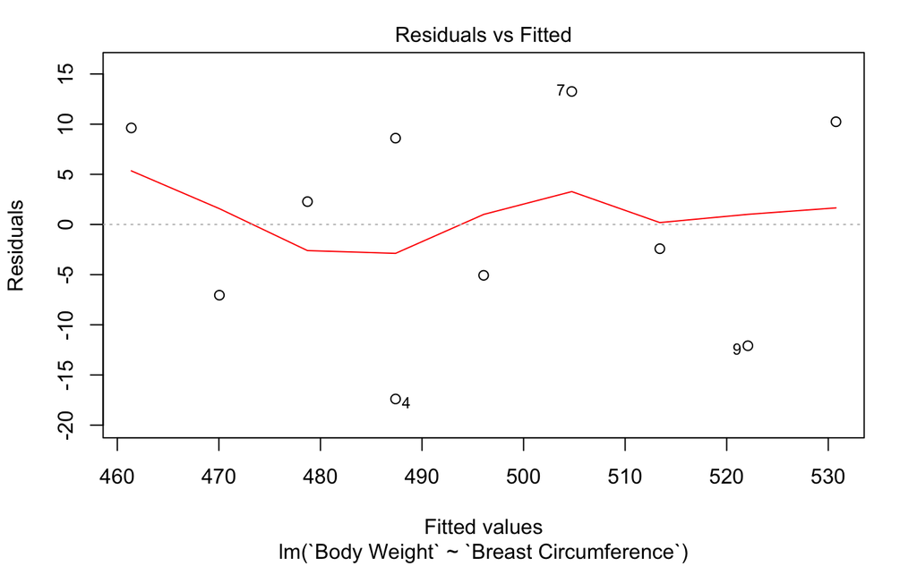

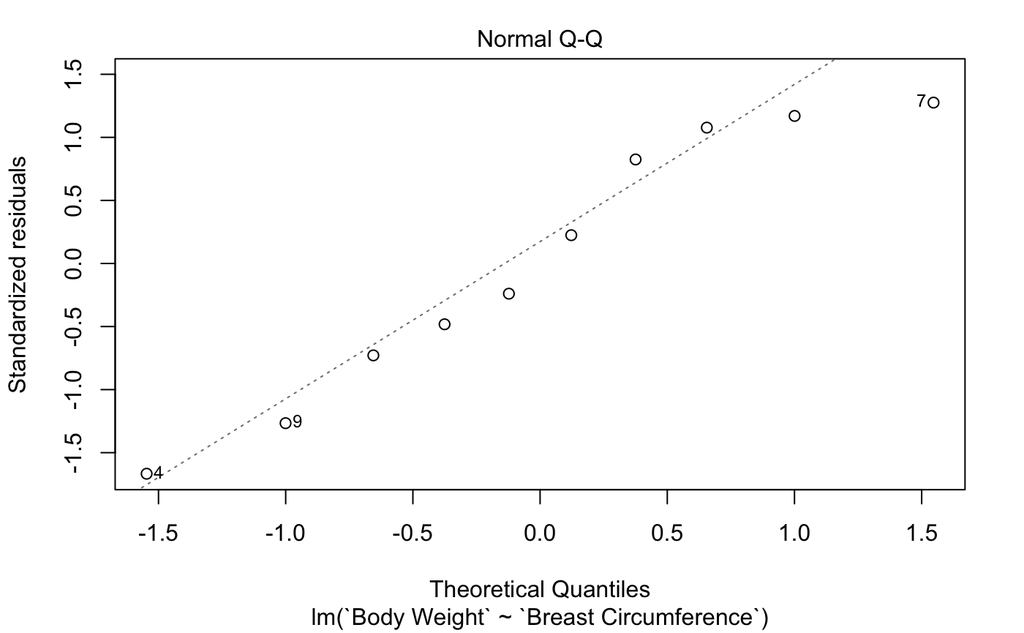

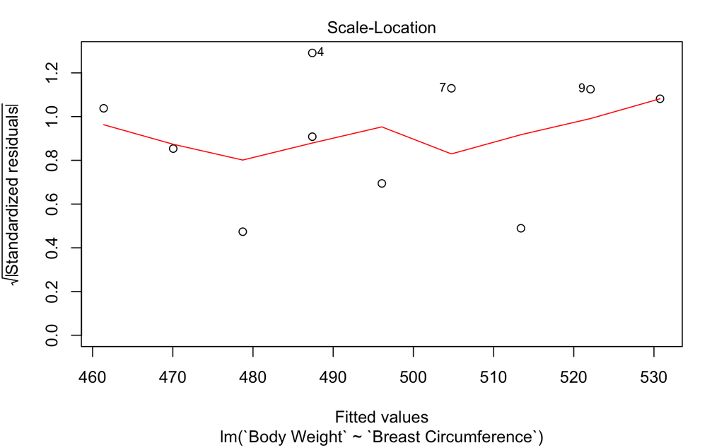

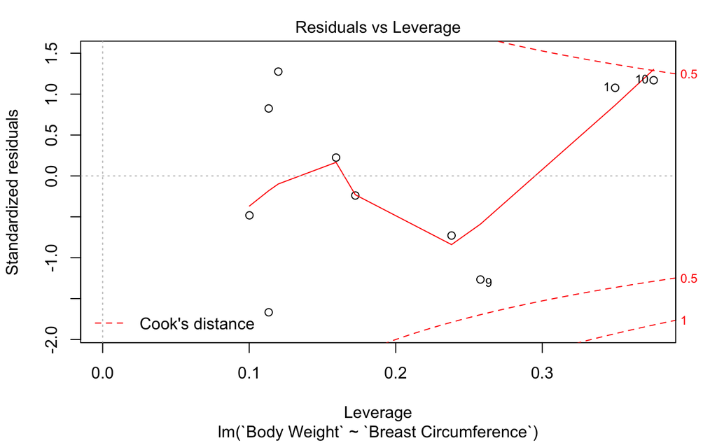

```r
plot(lm_bw_bc_inter)
```